# Test a Perceptual Phenomenon

### Analyzing the Stroop Effect

Perform the analysis in the space below. Remember to follow [the instructions](https://docs.google.com/document/d/1-OkpZLjG_kX9J6LIQ5IltsqMzVWjh36QpnP2RYpVdPU/pub?embedded=True) and review the [project rubric](https://review.udacity.com/#!/rubrics/71/view) before submitting. Once you've completed the analysis and write-up, download this file as a PDF or HTML file, upload that PDF/HTML into the workspace here (click on the orange Jupyter icon in the upper left then Upload), then use the Submit Project button at the bottom of this page. This will create a zip file containing both this .ipynb doc and the PDF/HTML doc that will be submitted for your project.

(1) What is the independent variable? What is the dependent variable?

- Independent variable: The congruency of the color and text
- Dependent variable: The duration to recognize the colors and the texts

(2) What is an appropriate set of hypotheses for this task? Specify your null and alternative hypotheses, and clearly define any notation used. Justify your choices.

**\begin{align} H_{0} : \mu_{inc} - \mu_{con} \leq 0 \\ H_{1} : \mu_{inc} - \mu_{con} > 0 \\ \end{align}**

- Null hypothesis: Naming the ink colors of incongruent words takes same time or less time than naming the ink colors of congruent words
- Alternative hypothesis: Naming the ink colors of incongruent words takes more time than naming the ink colors of congruent words

> I want to assume that the naming the ink colors of incongruent words takes more time than naming the ink colors of congruent words if the naming incongruent words proves to take definitely more time at a Type I error rate of 5%.

> Paired t-test will be performed to find out the statistical significance of the hypothesis, since I assume that the congruency of the color and the text is dependent on the response time. The reason why I chose t-test is that we are comparing the reaction time of a sample from same population in two different conditions. Also, I assume that the sample distribution is normal to practice the t-test.

(3) Report some descriptive statistics regarding this dataset. Include at least one measure of central tendency and at least one measure of variability. The name of the data file is 'stroopdata.csv'.

```python
# Import necessary packages for the test
import pandas as pd
import matplotlib.pyplot as plt
import scipy.stats as stats
% matplotlib inline

# Read the data file
df = pd.read_csv('stroopdata.csv')

df.head()
```

|  | Congruent | Incongruent |
| --- | --- | --- |
| 0 | 12.079 | 19.278 |
| 1 | 16.791 | 18.741 |
| 2 | 9.564 | 21.214 |
| 3 | 8.630 | 15.687 |
| 4 | 14.669 | 22.803 |

```python
# Describe the DataFrame
df.describe()
```

|  | Congruent | Incongruent |
| --- | --- | --- |
| count | 24.000000 | 24.000000 |
| mean | 14.051125 | 22.015917 |
| std | 3.559358 | 4.797057 |
| min | 8.630000 | 15.687000 |
| 25% | 11.895250 | 18.716750 |
| 50% | 14.356500 | 21.017500 |
| 75% | 16.200750 | 24.051500 |
| max | 22.328000 | 35.255000 |

(4) Provide one or two visualizations that show the distribution of the sample data. Write one or two sentences noting what you observe about the plot or plots.

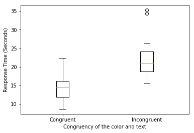

```python
# Box plot of congruent and incongruent groups
plt.boxplot(df.transpose(), labels=['Congruent', 'Incongruent']);
plt.ylabel('Response Time (Seconds)');
plt.xlabel('Congruency of the color and text');
```

> From the box plot, we can find out incongruent words relatively took more time to response than congruent words. Also, we can see that there are outliers, which took more than 30 seconds to response in the incongruent group.

(5) Now, perform the statistical test and report your results. What is your confidence level or Type I error associated with your test? What is your conclusion regarding the hypotheses you set up? Did the results match up with your expectations? **Hint:** Think about what is being measured on each individual, and what statistic best captures how an individual reacts in each environment.

```python
# Perform the paired t-test
t, p = stats.ttest_rel(df['Congruent'], df['Incongruent'])

# divide p-value by 2 because the test_rel function returns p-value for two-tailed t-test.
t, p/2
```

```
(-8.020706944109957, 2.051500292855589e-08)
```

> Confidence Level : 95%

> Since the p-value is very small, which is smaller than 0.05, we can reject the null hypothesis. Therefore, "naming the incongruent words takes more time than naming the congruent words" is statistically significant.